# PojectII

Jan Anders, Varsha Budihal, Rachel Gonzales, Shraddha Bhvarsar

April 29, 2019

Setting up the normalization function

```r
normalize <- function(x){
  ((x-min(x)) / (max(x) - min(x)))
}
```

Reading in the original dataset and reapplying the data cleaning done in P1.

```r
movies_orig <- read.csv("C:/Users/Admin/Documents/movies.csv") # Enter valid location of the data file here

movies_orig <- movies_orig %>% filter(budget != 0)

#making sure all categorical variables are encoded as character
movies <- movies_orig %>% mutate(writer = as.character(writer), star = as.character(star), rating = as.character(rating),
                            director = as.character(director), country = as.character(country), company = as.character(company))
```

Tranforming the variables for better predictions and conversion. Two versions of transformation were tried, with a normal min-max transformation not doing the trick.

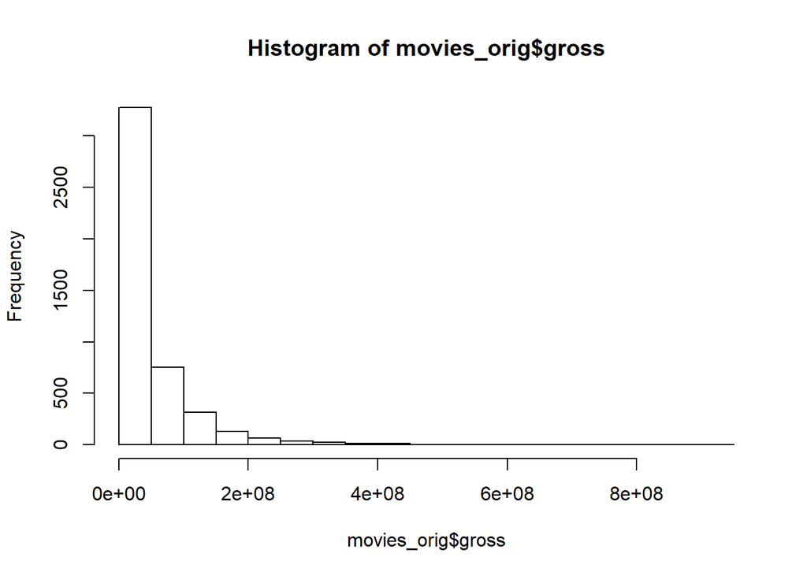

```r
hist(movies_orig$gross)
```

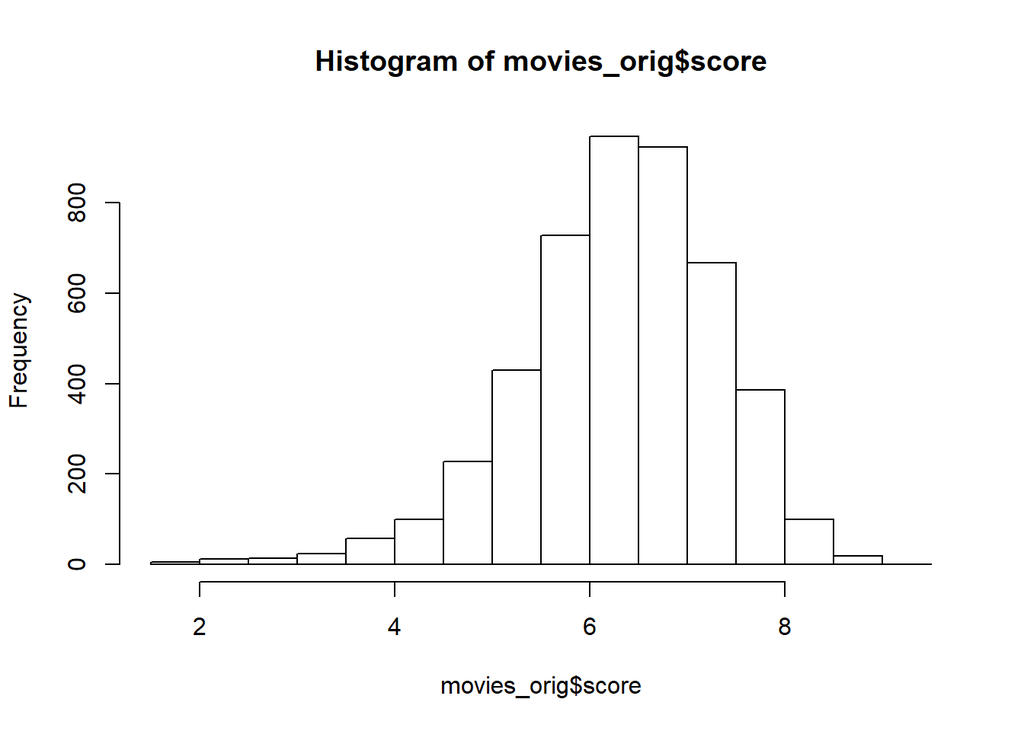

```r
hist(movies_orig$score)
```

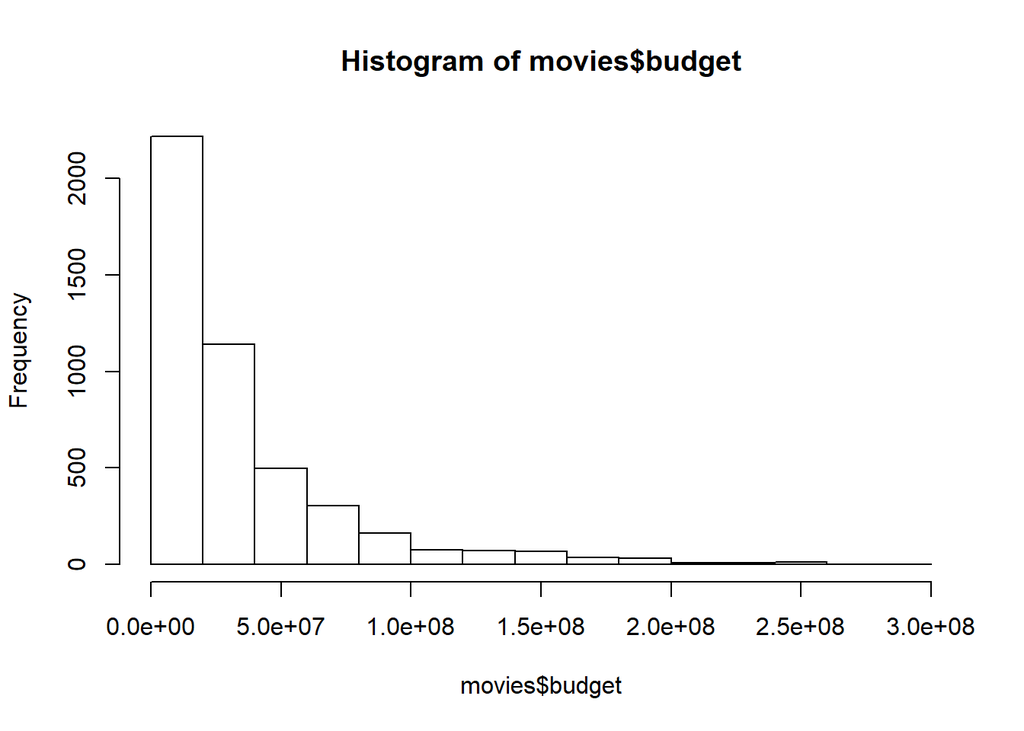

```r
# We will try to match the distribution of the gross variable with the distr. of the score variable.

movies_norm <- movies %>% mutate(gross = normalize(gross), runtime = normalize(runtime), score = normalize(score), budget = normalize((budget)))

# Terrible distributions, that's why we log-transform the gross and budget variables
# This makes interpretation harder though.
hist(movies$budget)
```

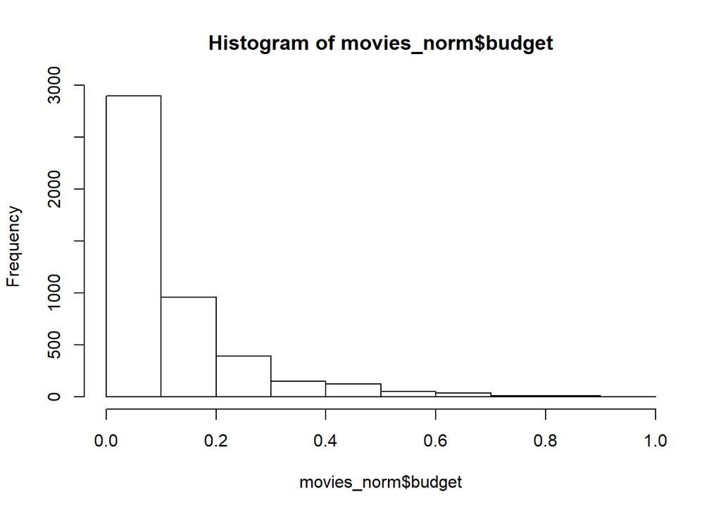

```r
hist(movies_norm$budget)
```

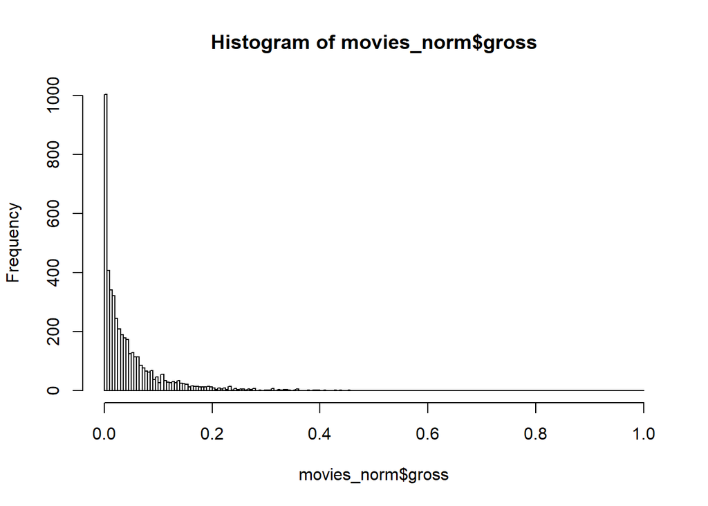

```r
hist(movies_norm$gross, 200)
```

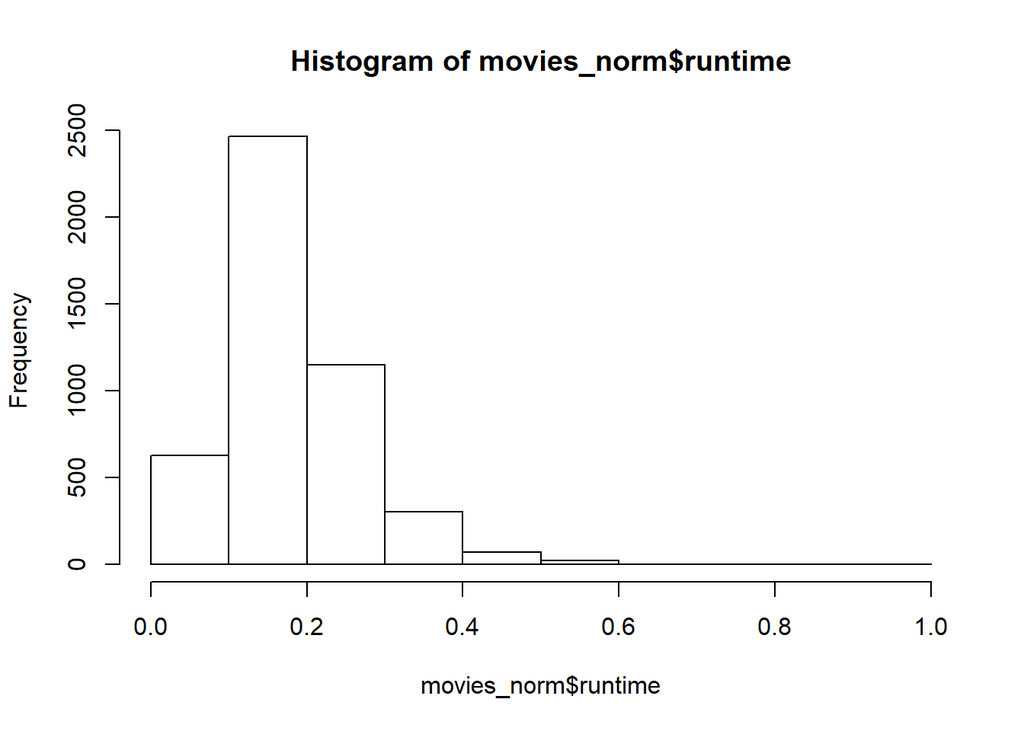

```r
hist(movies_norm$runtime)
```

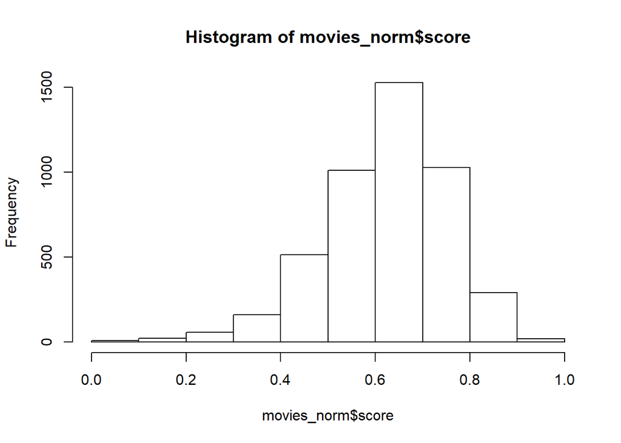

```r
hist(movies_norm$score)
```

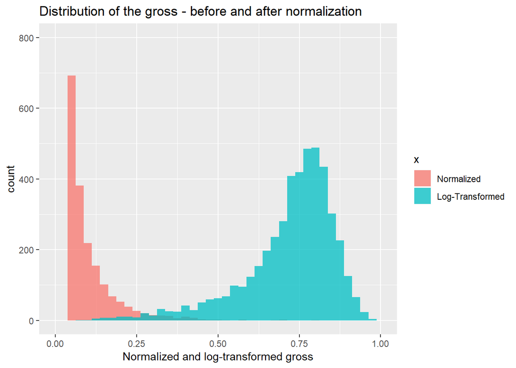

```r
# Log transforming the variables
movies_norm_log <- movies %>% ungroup() %>% mutate(gross = normalize(log(gross)),
                                     runtime = normalize(runtime),
                                     score = normalize(score),
                                     budget = normalize(log(budget)))

dist_frame_gross <- data.frame(gross = movies_norm$gross, x = "Normalized") %>%
          rbind(data.frame(gross = movies_norm_log$gross, x = "Log-Transformed"))

dist_frame_budget <- data.frame(budget = movies_norm$budget, x = "Normalized") %>%
          rbind(data.frame(budget = movies_norm_log$budget, x = "Log-Transformed"))

ggplot(data = dist_frame_gross, aes(fill = x)) +
  geom_histogram(aes(x= gross), binwidth =0.025, position = "identity", alpha = 0.75) +
  ggtitle("Distribution of the gross - before and after normalization") + xlim(c(0,1)) +
  xlab("Normalized and log-transformed gross") + ylim(0, 800)
```

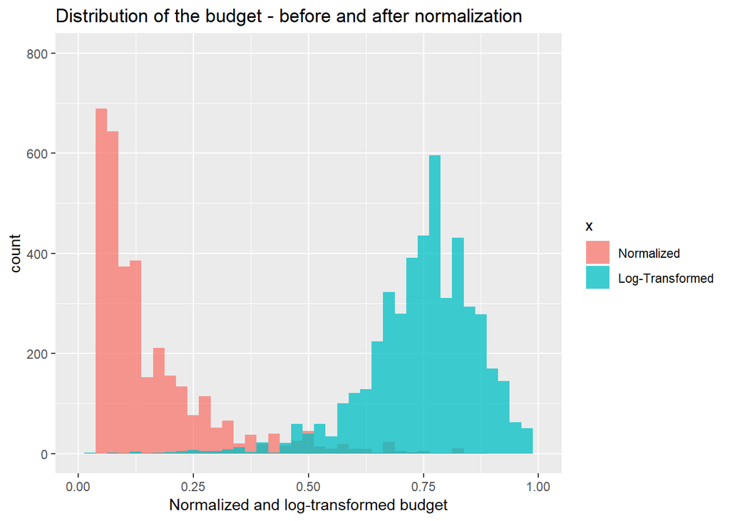

```r
ggplot(data = dist_frame_budget, aes(fill = x)) +
  geom_histogram(aes(x= budget), binwidth =0.025, position = "identity", alpha = 0.75) +
  ggtitle("Distribution of the budget - before and after normalization") + xlim(c(0,1)) +
  xlab("Normalized and log-transformed budget") + ylim(0, 800)
```

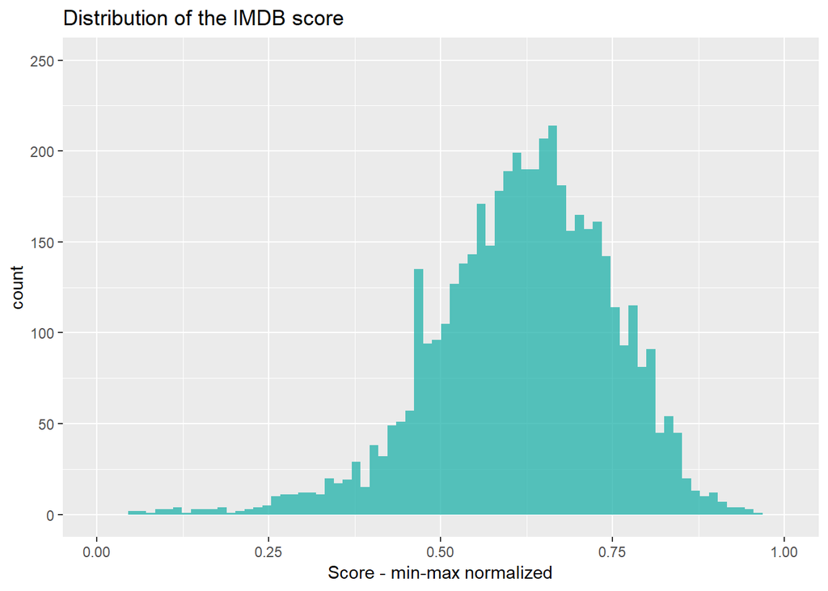

```r
ggplot(data = movies_norm_log) +
  geom_histogram(aes(x= score), binwidth = 0.013, position = "identity", alpha = 0.75, fill = "lightseagreen") +
  ggtitle("Distribution of the IMDB score") + xlim(c(0,1)) +
  xlab("Score - min-max normalized") + ylim(0, 250)
```

```r
movies <- movies_norm_log
```

Feature engineering

```r
# It would be better to get the amount of movies that a star/director/company/writer has produced until the date of the observation
# but we were not able to find out how to do that. This will do fine as well
actor_number <- movies %>% group_by(star) %>% summarize(actor_n = n())
director_number <- movies %>% group_by(director) %>% summarize(director_n = n())
company_number <- movies %>% group_by(company) %>% summarize(company_n = n())
writer_number <- movies %>% group_by(writer) %>% summarize(writer_n = n())
country_number <- movies %>% group_by(country) %>% summarize(country_n = n())


# Joining in the newly created features
movies <- movies %>% inner_join(actor_number, by = c("star")) %>%
           inner_join(director_number, by = c("director")) %>%
           inner_join(company_number, by = c("company")) %>%
           inner_join(writer_number, by = c("writer")) %>%
           inner_join(country_number, by = c("country"))

# We could also think about encoding the coutry variable as dummy, as it only contains 41 factors, which is quite a lot.
# The function lm does that automatically though, if we find significant impacts of one country,
# we might just create one variable for this one value. The same goes for "rating" and "genre".
```

```r
# Adding one so the dependent variable is never below 1 and therefore messes up MSE calculation
movies <- movies %>% mutate(success = 1 + gross + score, success_diff = gross - score, success_abs_diff = abs(gross - score))

str(movies)
```

```
## 'data.frame':    4638 obs. of  23 variables:
##  $ budget          : num  0.665 0.638 0.723 0.743 0.676 ...
##  $ company         : chr  "Columbia Pictures Corporation" "Paramount Pictures" "Paramount Pictures" "Twentieth Century Fox Film Corporation" ...
##  $ country         : chr  "USA" "USA" "USA" "USA" ...
##  $ director        : chr  "Rob Reiner" "John Hughes" "Tony Scott" "James Cameron" ...
##  $ genre           : Factor w/ 17 levels "Action","Adventure",..: 2 5 1 1 2 7 2 7 5 7 ...
##  $ gross           : num  0.807 0.826 0.889 0.839 0.737 ...
##  $ name            : Factor w/ 6731 levels "'71","'night, Mother",..: 4671 1829 6210 299 1880 3911 2890 781 3969 5312 ...
##  $ rating          : chr  "R" "PG-13" "PG" "R" ...
##  $ released        : Factor w/ 2403 levels "1/1/2004","1/1/2014",..: 2083 1585 1410 1837 1984 961 1684 267 932 2029 ...
##  $ runtime         : num  0.0948 0.1611 0.1943 0.3223 0.0995 ...
##  $ score           : num  0.846 0.808 0.692 0.885 0.692 ...
##  $ star            : chr  "Wil Wheaton" "Matthew Broderick" "Tom Cruise" "Sigourney Weaver" ...
##  $ votes           : int  299174 264740 236909 540152 36636 317585 102879 146768 60565 129698 ...
##  $ writer          : chr  "Stephen King" "John Hughes" "Jim Cash" "James Cameron" ...
##  $ year            : int  1986 1986 1986 1986 1986 1986 1986 1986 1986 1986 ...
##  $ actor_n         : int  1 9 27 9 1 10 1 1 3 3 ...
##  $ director_n      : int  14 4 14 6 3 17 1 6 8 8 ...
##  $ company_n       : int  137 222 222 174 89 4 1 15 222 1 ...
##  $ writer_n        : int  20 14 2 7 1 3 1 4 14 1 ...
##  $ country_n       : int  3726 3726 3726 3726 3726 366 366 3726 3726 3726 ...
##  $ success         : num  2.65 2.63 2.58 2.72 2.43 ...
##  $ success_diff    : num  -0.0395 0.0186 0.1971 -0.0453 0.045 ...
##  $ success_abs_diff: num  0.0395 0.0186 0.1971 0.0453 0.045 ...
```

We reduce the dataset to only the important variables

```r
movies <- movies %>% select(gross, score, success, success_diff, year, budget, country, rating, genre, runtime, votes, actor_n, director_n, company_n, writer_n, country_n)
```

The following code is trying to find the best model using a forward selection approach:

```r
model <- lm(data = movies, success ~ year + budget)
summary(model)
```

```
##
## Call:
## lm(formula = success ~ year + budget, data = movies)
##
## Residuals:
##      Min       1Q   Median       3Q      Max
## -0.94296 -0.10491  0.01534  0.12389  0.57779
##
## Coefficients:
##              Estimate Std. Error t value Pr(>|t|)
## (Intercept) 1.6233464  0.6524904   2.488   0.0129 *
## year        0.0001055  0.0003275   0.322   0.7473
## budget      0.6809092  0.0228280  29.828   <2e-16 ***
## ---
## Signif. codes:  0 '***' 0.001 '**' 0.01 '*' 0.05 '.' 0.1 ' ' 1
##
## Residual standard error: 0.1847 on 4635 degrees of freedom
## Multiple R-squared:  0.1676, Adjusted R-squared:  0.1673
## F-statistic: 466.7 on 2 and 4635 DF,  p-value: < 2.2e-16
```

```r
model2 <- lm(data = movies, success ~ year + budget + actor_n + director_n)
summary(model2)
```

```
##
## Call:
## lm(formula = success ~ year + budget + actor_n + director_n,
##     data = movies)
##
## Residuals:
##      Min       1Q   Median       3Q      Max
## -0.90450 -0.10082  0.01443  0.11869  0.51919
##
## Coefficients:
##              Estimate Std. Error t value Pr(>|t|)
## (Intercept) 0.0400986  0.6389825   0.063  0.94997
## year        0.0009238  0.0003209   2.879  0.00401 **
## budget      0.5198514  0.0243811  21.322  < 2e-16 ***
## actor_n     0.0026650  0.0003390   7.861  4.7e-15 ***
## director_n  0.0079740  0.0005739  13.893  < 2e-16 ***
## ---
## Signif. codes:  0 '***' 0.001 '**' 0.01 '*' 0.05 '.' 0.1 ' ' 1
##
## Residual standard error: 0.1789 on 4633 degrees of freedom
## Multiple R-squared:  0.2188, Adjusted R-squared:  0.2181
## F-statistic: 324.4 on 4 and 4633 DF,  p-value: < 2.2e-16
```

how many votes from which country due to which actor contributed to the success of a movie?

```r
model3 <- lm(data=movies, success ~ year + budget + actor_n + director_n + writer_n + country_n + rating)
summary(model3)
```

```
##
## Call:
## lm(formula = success ~ year + budget + actor_n + director_n +
##     writer_n + country_n + rating, data = movies)
##
## Residuals:
##      Min       1Q   Median       3Q      Max
## -0.90345 -0.09920  0.01473  0.11862  0.49698
##
## Coefficients:
##                       Estimate Std. Error t value Pr(>|t|)
## (Intercept)         -2.982e-01  6.460e-01  -0.462 0.644365
## year                 1.148e-03  3.249e-04   3.532 0.000416 ***
## budget               4.795e-01  2.667e-02  17.981  < 2e-16 ***
## actor_n              2.917e-03  3.424e-04   8.518  < 2e-16 ***
## director_n           7.288e-03  6.227e-04  11.704  < 2e-16 ***
## writer_n             3.492e-03  8.771e-04   3.981 6.97e-05 ***
## country_n            7.501e-07  1.892e-06   0.396 0.691774
## ratingNC-17         -1.272e-01  6.221e-02  -2.045 0.040863 *
## ratingNOT RATED     -1.822e-01  3.494e-02  -5.215 1.92e-07 ***
## ratingNot specified -3.912e-02  9.101e-02  -0.430 0.667338
## ratingPG            -8.390e-02  1.919e-02  -4.371 1.26e-05 ***
## ratingPG-13         -9.084e-02  1.857e-02  -4.891 1.03e-06 ***
## ratingR             -9.494e-02  1.856e-02  -5.114 3.28e-07 ***
## ratingUNRATED       -1.162e-01  4.456e-02  -2.608 0.009149 **
## ---
## Signif. codes:  0 '***' 0.001 '**' 0.01 '*' 0.05 '.' 0.1 ' ' 1
##
## Residual standard error: 0.1781 on 4624 degrees of freedom
## Multiple R-squared:  0.2277, Adjusted R-squared:  0.2255
## F-statistic: 104.8 on 13 and 4624 DF,  p-value: < 2.2e-16
```

```r
model4 <- lm(data=movies, success ~ year + budget + actor_n + director_n + writer_n + country_n + runtime + genre)
summary(model4)
```

```
##
## Call:
## lm(formula = success ~ year + budget + actor_n + director_n +
##     writer_n + country_n + runtime + genre, data = movies)
##
## Residuals:
##      Min       1Q   Median       3Q      Max
## -0.86290 -0.09056  0.01618  0.11344  0.48769
##
## Coefficients:
##                  Estimate Std. Error t value Pr(>|t|)
## (Intercept)     6.625e-01  6.038e-01   1.097  0.27254
## year            5.973e-04  3.031e-04   1.970  0.04884 *
## budget          3.266e-01  2.592e-02  12.602  < 2e-16 ***
## actor_n         2.387e-03  3.234e-04   7.381 1.85e-13 ***
## director_n      4.632e-03  5.980e-04   7.746 1.16e-14 ***
## writer_n        5.147e-03  8.279e-04   6.217 5.52e-10 ***
## country_n       7.901e-06  1.789e-06   4.417 1.02e-05 ***
## runtime         7.315e-01  3.463e-02  21.124  < 2e-16 ***
## genreAdventure  3.636e-02  1.105e-02   3.290  0.00101 **
## genreAnimation  2.026e-01  1.267e-02  15.985  < 2e-16 ***
## genreBiography  5.926e-02  1.230e-02   4.818 1.49e-06 ***
## genreComedy     1.477e-02  7.149e-03   2.066  0.03885 *
## genreCrime      1.439e-02  1.044e-02   1.378  0.16837
## genreDrama      1.658e-02  8.204e-03   2.021  0.04332 *
## genreFamily    -2.492e-02  6.837e-02  -0.364  0.71555
## genreFantasy   -4.285e-02  3.157e-02  -1.357  0.17476
## genreHorror    -1.070e-03  1.266e-02  -0.085  0.93264
## genreMusical   -3.172e-01  1.668e-01  -1.901  0.05731 .
## genreMystery    2.062e-02  3.045e-02   0.677  0.49839
## genreRomance   -1.771e-02  7.479e-02  -0.237  0.81287
## genreSci-Fi     5.311e-02  5.058e-02   1.050  0.29371
## genreThriller  -1.507e-01  5.923e-02  -2.544  0.01100 *
## genreWestern    1.308e-02  1.181e-01   0.111  0.91186
## ---
## Signif. codes:  0 '***' 0.001 '**' 0.01 '*' 0.05 '.' 0.1 ' ' 1
##
## Residual standard error: 0.1667 on 4615 degrees of freedom
## Multiple R-squared:  0.3248, Adjusted R-squared:  0.3216
## F-statistic: 100.9 on 22 and 4615 DF,  p-value: < 2.2e-16
```

Creating dummy variables for the most important genres and rating.

```r
movies <- movies %>% filter(genre != "Western") %>% mutate(genre_Crime = ifelse(genre == "Crime", 1, 0),
                                                           genre_Drame = ifelse(genre == "Drama", 1, 0),
                                                           genre_Animation = ifelse(genre == "Animation", 1, 0),
                                                           genre_Biography = ifelse(genre == "Biography", 1, 0),
                                                           genre_Comedy = ifelse(genre == "Comedy", 1, 0),
                                                           genre_Adventure = ifelse(genre == "Adventure", 1, 0),
                                                           rating_r = ifelse(rating == "R", 1, 0),
                                                           rating_pg13 = ifelse(rating == "PG-13", 1, 0),
                                                           rating_pg = ifelse(rating == "PG", 1, 0))


# Exporting the finished dataset
#write.csv(movies, "")
```

The best model we were able to find using linear regression, now using test and training data. The used variables are all statistically significant with a pvalue of at least < 0.05. The Adjusted RSquared is 32%.

```r
set.seed(42)
train <- movies %>% sample_frac(0.8)
test <- movies %>% anti_join(train)
```

```r
lin_model <- lm(data = train, success ~ budget + runtime + genre_Adventure +
                                    genre_Animation + genre_Biography +
                                    actor_n + writer_n + director_n +
                                    company_n)
summary(lin_model)
```

```
##
## Call:
## lm(formula = success ~ budget + runtime + genre_Adventure + genre_Animation +
##     genre_Biography + actor_n + writer_n + director_n + company_n,
##     data = train)
##
## Residuals:
##      Min       1Q   Median       3Q      Max
## -0.83683 -0.08945  0.01641  0.11472  0.45668
##
## Coefficients:
##                  Estimate Std. Error t value Pr(>|t|)
## (Intercept)     1.934e+00  1.812e-02 106.712  < 2e-16 ***
## budget          2.511e-01  2.777e-02   9.045  < 2e-16 ***
## runtime         7.100e-01  3.659e-02  19.404  < 2e-16 ***
## genre_Adventure 2.887e-02  1.173e-02   2.462   0.0139 *
## genre_Animation 2.092e-01  1.331e-02  15.717  < 2e-16 ***
## genre_Biography 5.908e-02  1.229e-02   4.805 1.61e-06 ***
## actor_n         2.379e-03  3.559e-04   6.686 2.64e-11 ***
## writer_n        5.051e-03  9.284e-04   5.441 5.66e-08 ***
## director_n      4.199e-03  6.635e-04   6.329 2.77e-10 ***
## company_n       2.706e-04  3.281e-05   8.248  < 2e-16 ***
## ---
## Signif. codes:  0 '***' 0.001 '**' 0.01 '*' 0.05 '.' 0.1 ' ' 1
##
## Residual standard error: 0.1667 on 3699 degrees of freedom
## Multiple R-squared:  0.3249, Adjusted R-squared:  0.3233
## F-statistic: 197.8 on 9 and 3699 DF,  p-value: < 2.2e-16
```

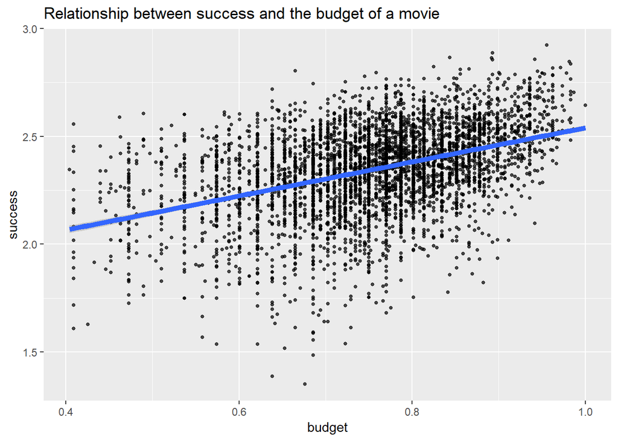

```r
# Visualizing (parts of) the model

ggplot(data=movies %>% filter(budget > 0.4), aes(x = budget, y = success )) + geom_point(alpha = 0.7, size = 1) + geom_smooth(method = lm, size = 2) + ggtitle("Relationship between success and the budget of a movie")
```

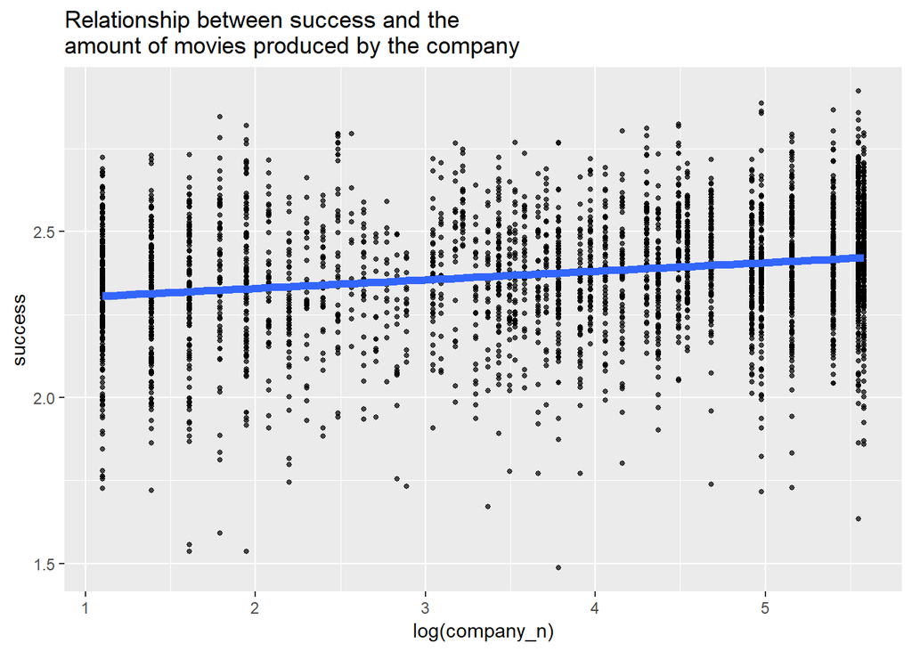

```r
ggplot(data=movies %>% filter(company_n > 2), aes(x = log(company_n), y = success )) + geom_point(alpha = 0.7, size = 1) + geom_smooth(method = lm, size = 2) + ggtitle("Relationship between success and the \namount of movies produced by the company")
```

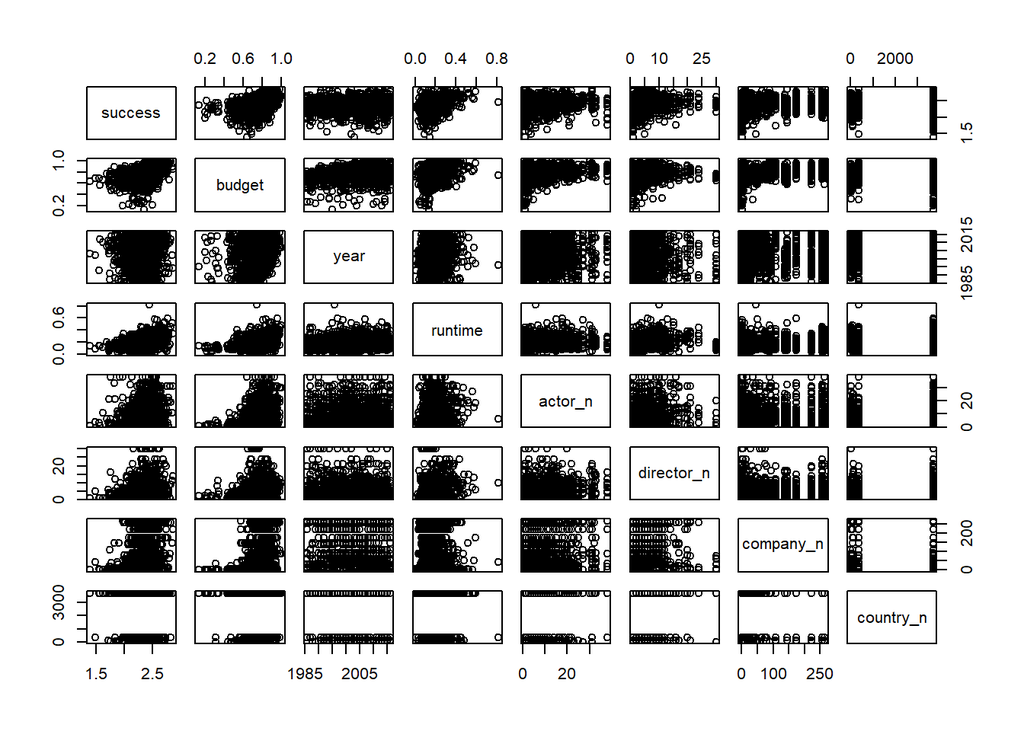

```r
plot(movies %>% sample_frac(0.3) %>% select(success, budget, year, runtime, actor_n, director_n, company_n, country_n))
```

```r
# Still need to construct the plane variable
#p <- plot_ly(data = movies, z = ~success, x = ~budget, y =~runtime) %>% add_markers()
#p %>% add_surface(z = ~plane, x = ~budget, y = ~runtime) %>%
#  layout(showlegend = T)
```

We wrote a function to calculate the most important measures to be able to tell the performance of model more quickly while fitting:

```r
# Outputs the most important evaluative scores to the console
# MAE: MEAN ABSOLUTE ERROR. The lower the better.
# RMSE : ROOT MEAN SQUARED ERROR. The lower the better, best is 1, should at least be 0.5
# MSE: MEAN SQUARED ERROR. The closer to 0 the better. Can (and should be!) very small. Most important measure for model bias.
# MAPE: MEAN ABSOLUTE PERCENTAGE ERROR. Lower the better
# MPE: MEAN PERCENTAGE ERROR. closer to 0 the better.  Should be very close to 0, same as MSE.
# R Squared: The higher the better, best being 1.

KPI <- function(actual, pred, MSE = TRUE, RMSE = TRUE, MAE = TRUE, MAPE = FALSE, MPE = FALSE, RSquared = TRUE){
  frame <- data.frame(a = actual, p = pred) %>% mutate(diff = a-p, absdiff = abs(a-p),
                                                       percdiff = diff/a, percabsdiff = absdiff/a) %>%
    mutate(percdiff = ifelse(is.finite(percdiff), percdiff, 0),
           percabsdiff = ifelse(is.finite(percabsdiff), percabsdiff, 0))
  resframe <- data.frame(Measure=0)
  if(MSE) {
    kpi1 = mean(frame$diff)
    resframe <- resframe %>% cbind(MSE = kpi1)
  }
  if(RMSE){
    kpi2 = sqrt(mean(frame$diff * frame$diff))
    resframe <- resframe %>% cbind(RMSE = kpi2)
  }
  if(MAE){
    kpi3 = mean(frame$absdiff)
    resframe <- resframe %>% cbind(MAE = kpi3)
  }
  if(RSquared){
    kpi4 = cor(actual, pred) ^ 2
    resframe <- resframe %>% cbind(RSquared = kpi4)
  }
  if(MAPE){
    kpi5 = mean(frame$percabsdiff)
    resframe <- resframe %>% cbind(MAPE = kpi5)
  }
  if(MPE){
    kpi6 = mean(frame$percdiff)
    resframe <- resframe %>% cbind(MPE = kpi6)
  }
  return(resframe)
}
```

Applying the KPI function to the best linear model yields: RMSE 0.162 MAPE 5.4% MPE -0.5 % These results are good. The mean absolute error is 0.1, on a range of the dependent variable of 1.57 (1.35, 2.92)

The qq-plot is almost straight, showing that the residuals are almost normally distributed, which can also be seen in the histogram

```r
linear_model_predictions <- data.frame(act = test$success, pred = predict(lin_model, test))

KPI(linear_model_predictions$act, linear_model_predictions$pred, MAPE = T, MPE = T, MSE = T)
```

```
##   Measure         MSE      RMSE       MAE  RSquared       MAPE         MPE
## 1       0 0.001566879 0.1623499 0.1237058 0.3513758 0.05467271 -0.00481907
```

```r
#determining the range of the success variable
max(movies$success)-min(movies$success)
```

```
## [1] 1.571483
```

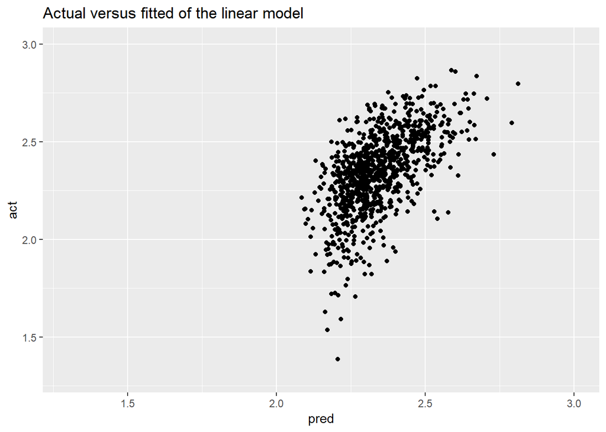

```r
# Plotting the model and residuals
ggplot(data = linear_model_predictions, aes(x= pred, y = act)) + geom_point() + ggtitle("Actual versus fitted of the linear model") + xlim(c(1.3,3)) + ylim(c(1.3,3))
```

```r
cor(linear_model_predictions$act,linear_model_predictions$pred )
```

```
## [1] 0.5927696
```

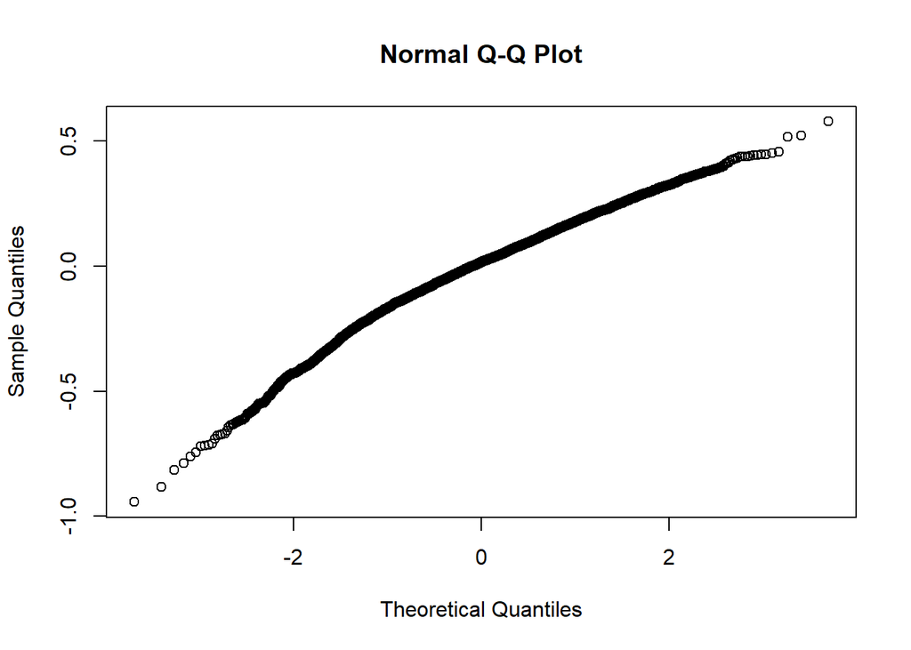

```r
qqnorm(model$residuals)
```

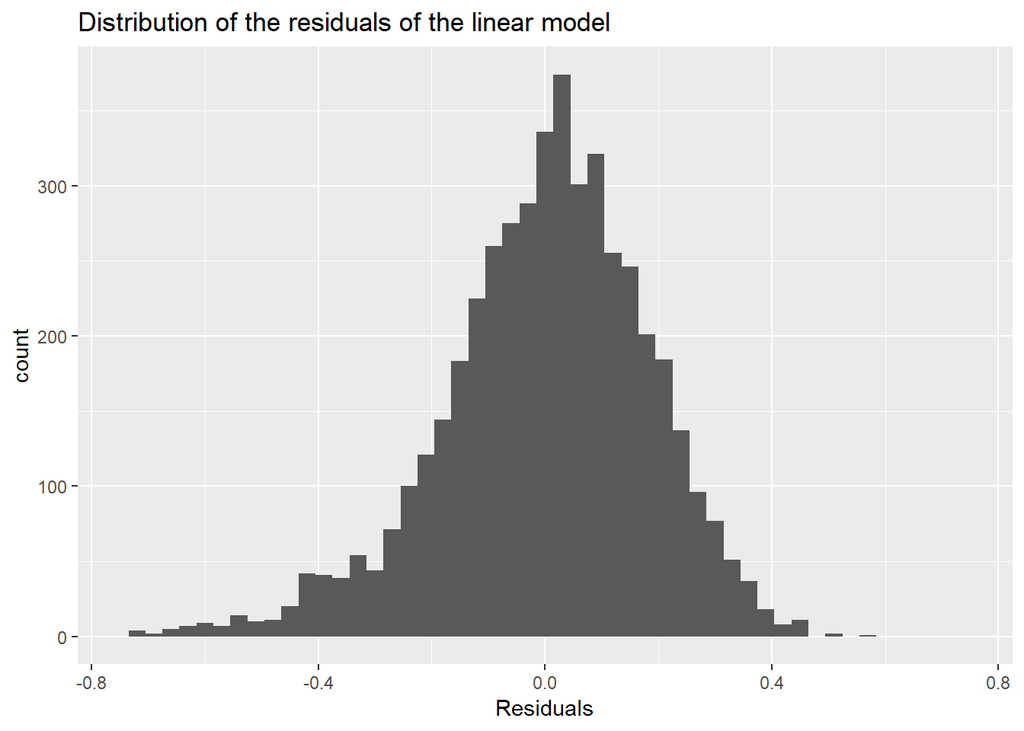

```r
ggplot(data = data.frame(Residuals=model$residuals), aes(x= Residuals)) + geom_histogram(binwidth =0.03) + ggtitle("Distribution of the residuals of the linear model") + xlim(c(-0.75,0.75))
```

```r
set.seed(100)
# original code replaced to enable comparability
#train <- sample(nrow(movies), 0.7 * nrow(movies), replace = FALSE)
#TrainSet <- movies[train,]
#ValidSet <- movies[-train,]
#summary(TrainSet)
#summary(ValidSet)

forest_model <- randomForest(success ~ budget + runtime + genre_Adventure + genre_Animation + genre_Biography +
                                    actor_n + writer_n + director_n + company_n,
                             data = train,ntree=500, mtry=6, importance = TRUE)
summary(forest_model)
```

```
##                 Length Class  Mode
## call               6   -none- call
## type               1   -none- character
## predicted       3709   -none- numeric
## mse              500   -none- numeric
## rsq              500   -none- numeric
## oob.times       3709   -none- numeric
## importance        18   -none- numeric
## importanceSD       9   -none- numeric
## localImportance    0   -none- NULL
## proximity          0   -none- NULL
## ntree              1   -none- numeric
## mtry               1   -none- numeric
## forest            11   -none- list
## coefs              0   -none- NULL
## y               3709   -none- numeric
## test               0   -none- NULL
## inbag              0   -none- NULL
## terms              3   terms  call
```

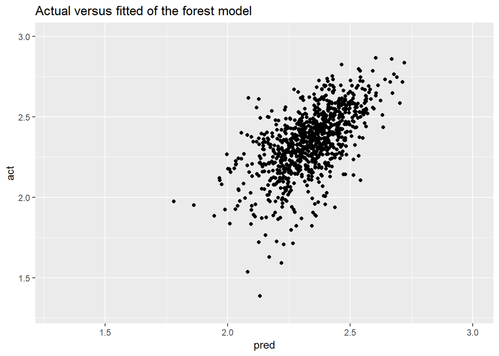

```r
# Predicting on validation set
predValid <- predict(forest_model, test, type = "class")

forest_model_predictions <- data.frame(act = test$success, pred = predValid)

ggplot(data = forest_model_predictions, aes(x= pred, y = act)) + geom_point() + ggtitle("Actual versus fitted of the forest model") + xlim(c(1.3,3)) + ylim(c(1.3,3))
```

```r
# Checking accuracy
KPI(a = forest_model_predictions$act, p = forest_model_predictions$pred, MAPE = T, MPE = T)
```

```
##   Measure         MSE      RMSE       MAE RSquared       MAPE          MPE
## 1       0 0.006396156 0.1591429 0.1213115 0.377205 0.05355801 -0.002197308
```

```r
# Learning rate of 0.2 and maximum tree depth of 5. Other pruning parameters left to standard, as this is just a test.
#feature_list <- c("success", "budget", "company", "country", "director", "genre", "rating", "released", "runtime",
                 # "star", "writer", "actor_n", "writer_n", "director_n", "company_n", "country_n")
feature_list <- c("success", "budget", "runtime", "actor_n", "writer_n", "director_n", "company_n", "country_n")
prediction_variable <- "success"
par <- list(eta = 0.2, max_depth = 5)

# Original code replaced for comparability
#train.data <- movies %>% select(feature_list) %>% sample_frac(0.8)
#test.data <- movies %>% select(feature_list) %>% anti_join(train.data)

train.data <- train %>% select(feature_list)
test.data <- test %>% select(feature_list)

matrix.train <- data.matrix(train.data %>% select(-prediction_variable))
matrix.test <- data.matrix(test.data %>% select(-prediction_variable))

train <- xgb.DMatrix(matrix.train, label = train.data$success)

# 300 rounds were found to produce the best results
xgb_model <- xgb.train(params = par, data = train, nrounds = 350)
prediction <- predict(xgb_model, matrix.test)

xgb_model_predictions <- test.data %>% select(prediction_variable) %>% mutate(pred = prediction, act = success)
KPI(actual = xgb_model_predictions$success, pred = xgb_model_predictions$pred, MAPE = T, MPE = T)
```

```
##   Measure         MSE      RMSE       MAE  RSquared       MAPE
## 1       0 0.002473913 0.1716702 0.1313413 0.3051127 0.05768874
##            MPE
## 1 -0.003773919
```

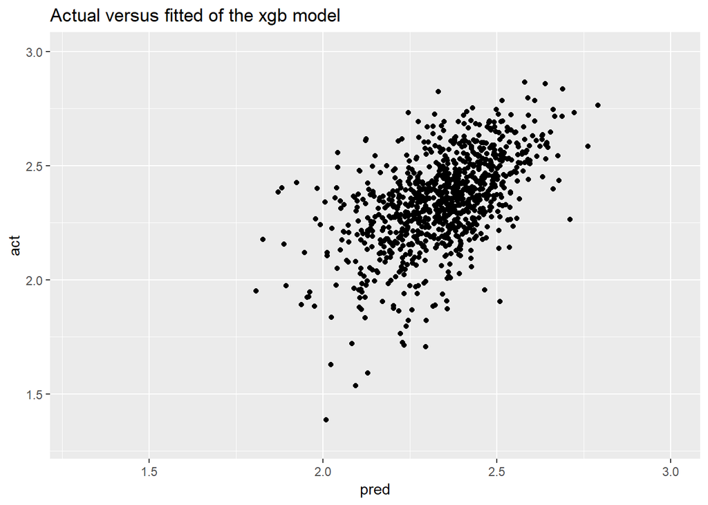

```r
ggplot(data = xgb_model_predictions, aes(x= pred, y = act)) + geom_point() + ggtitle("Actual versus fitted of the xgb model") + xlim(c(1.3,3)) + ylim(c(1.3,3))
```

Predicting marvel`s Endgame movie success (~3.05 (and 2.98) at the time of writing this using the best linear model) and making a final comparison plot for fun. We can see that randomForest and xgb look more alike, which makes sense. Linear regression does not predict values under a certain threshold, whereas the other two models go far below with their predictions. Still, there is a lot of room for improvement.

```r
predict(lin_model, data.frame(budget = 1 , genre_Animation = 0, genre_Adventure = 1,
                          genre_Horror = 0, genre_Biography = 0, genre_Comedy = 0,
                          director_n = 0, actor_n = 14, writer_n = 5 , company_n = 7,
                          runtime = 1, country_n = 3726))
```

```
##        1
## 2.984142
```

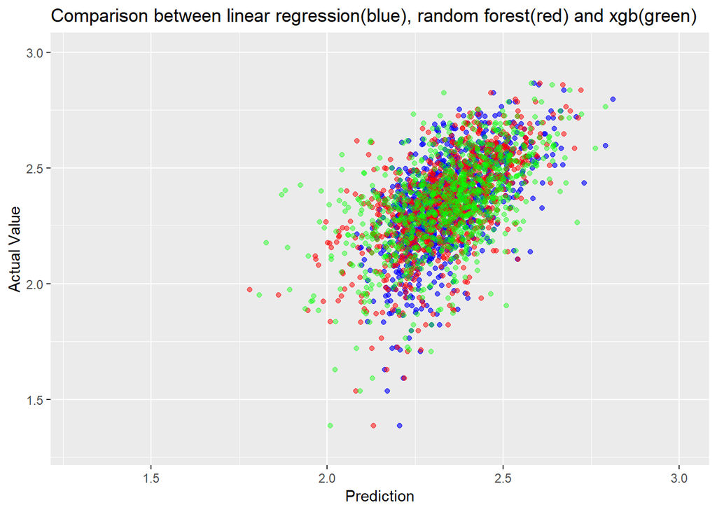

```r
#comparing all three models:

#all_pred_frame <- data.frame(actual_lm = linear_model_predictions$act, pred_lm = linear_model_predictions$)

ggplot() + geom_point(data = linear_model_predictions, aes(x = pred, y = act), color = "blue", alpha = 0.6) +
           geom_point(data = forest_model_predictions, aes(x = pred, y = act), color = "red", alpha = 0.5) +
           geom_point(data = xgb_model_predictions, aes(x = pred, y = act), color = "green", alpha = 0.4) +
           xlim(c(1.3,3)) + ylim(c(1.3,3)) + xlab("Prediction") + ylab("Actual Value") +
           ggtitle("Comparison between linear regression(blue), random forest(red) and xgb(green)")
```